# Within spp pollen size number tradeoff

Claire Smith

2023-07-28

### Goal

Testing for a within-species tradeoff in pollen size and number using linear regression: pollen number ~ pollen volume.

If n = number of grains per anther, s = pollen grain size, and e is the average resources for pollen production per flower, then we should expect

$$n \propto e s^a$$
where a is a constant determining the shape of the relationship between pollen number and size.

If we let c be some constant converting pollen size to number, we have

$$n = c s^a$$
.

If pollen size and number trade off, a should be negative. Since pollen diameter is our measure for s, and pollen from wind-pollinated plants tends to be spherical, we should expect s to be related to n by a power of 3. So if pollen diameter and number trade off, we should expect a to be equal to (or less than) -3.

I’ll test for a tradeoff between pollen diameter and number by log-transforming n and s,

$$log(n) = log(c s^a) = log(c) + a log(s)$$
and estimating a and the intercept log(c) using linear regression.

```r
library(tidyverse)
library(ggplot2)
library(lme4)
library(lmerTest)
source("theme_cs.R")
```

```r
# Read in individual-level pollen size and number data
prodfull <- read.csv("processed-data/size-prod-norep.csv", stringsAsFactors = T)
# head(prodfull)
# str(prodfull)
# summary(prodfull)

# Keep only entries with both size and prod values
prod <- prodfull %>%
  filter(!is.na(Avg_diam) & !is.na(Avg_pol_anth))

# Add log-transformed pollen per anther to dataframe
prod$Log_avg_pol_anth <- log(prod$Avg_pol_anth)
prod$Log_avg_diam <- log(prod$Avg_diam)

# Nest data by species to make it easier to handle
by_spp <- prod %>% group_by(Species, Sex_sys) %>%
  nest() %>%
  arrange(Sex_sys, Species) %>%
  # Keep only species with at least 10 entries %>%
  mutate(nind = purrr::map(data, nrow)) %>%
  filter(nind>=10)
# 23 species remaining
```

To test for tradeoffs in pollen size and number within species, I will build a linear model for each species predicting pollen production by pollen size.

First I’ll go through each species’ data and look at the distributions of pollen size and number to see how symmetric they are and if there are any obvious outliers.

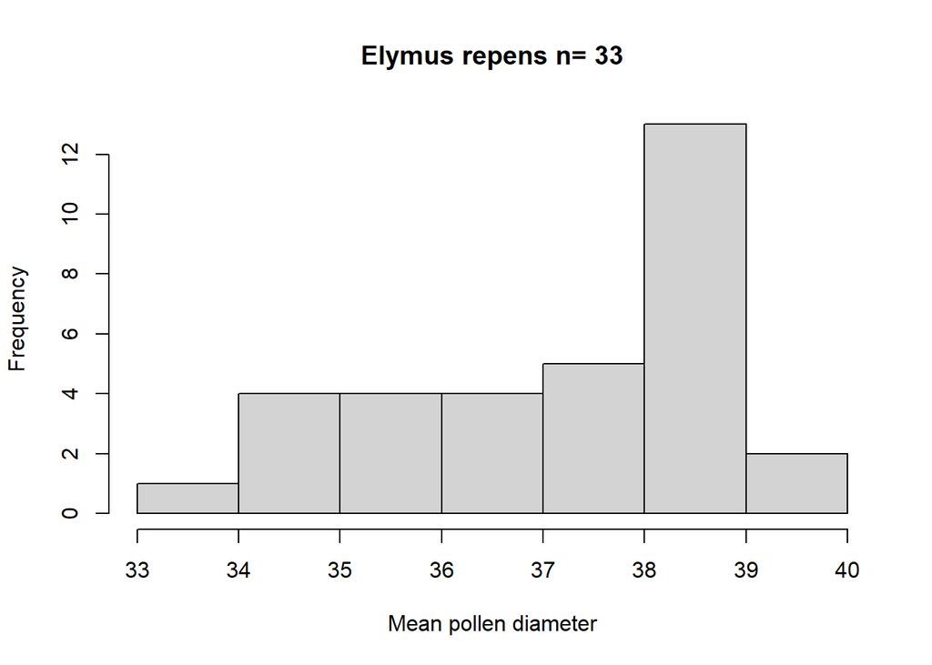

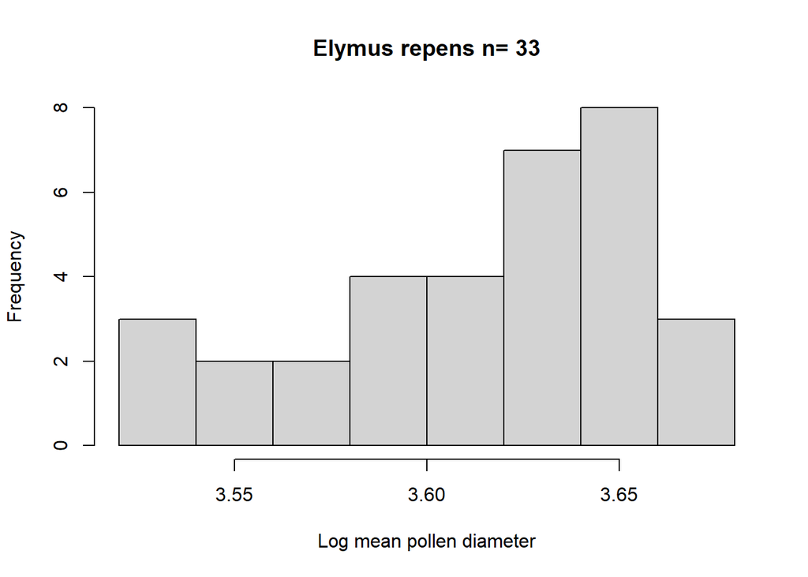

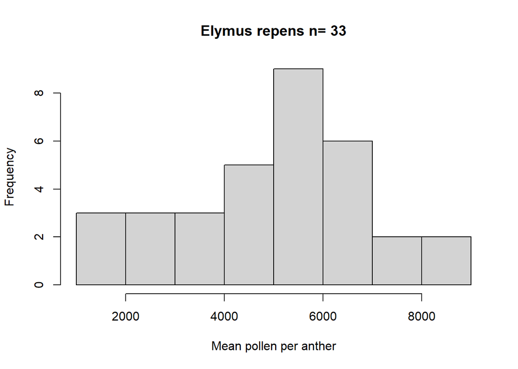

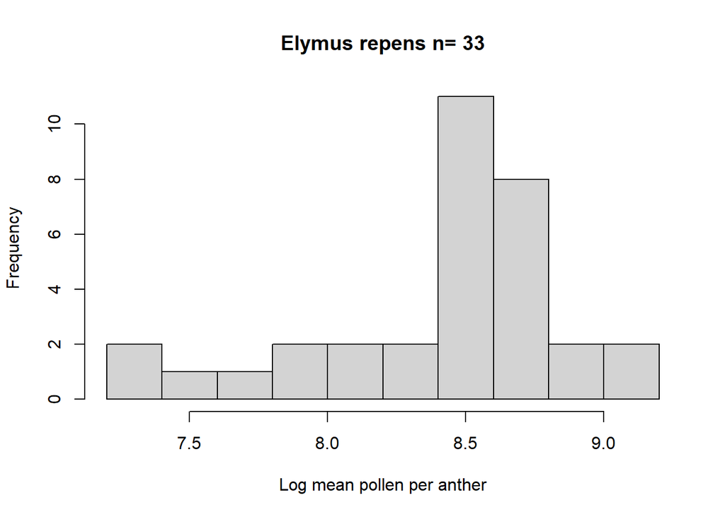

```r
#inspect distributions of mean pollen diam and pollen production for each species - are they symmetric? any obvious outliers?
#define function for this
checkfun <- function(df,i){
  spec = as.character(df[i,]$Species)
  n=length(df[i,]$data[[1]]$Avg_diam)
  hist(df[i,]$data[[1]]$Avg_diam, main=paste(spec, "n=",n), xlab="Mean pollen diameter")
  hist(log(df[i,]$data[[1]]$Avg_diam), main=paste(spec, "n=",n), xlab="Log mean pollen diameter")
  hist(df[i,]$data[[1]]$Avg_pol_anth, main=paste(spec, "n=",n), xlab="Mean pollen per anther")
  hist(log(df[i,]$data[[1]]$Avg_pol_anth), main=paste(spec, "n=",n), xlab="Log mean pollen per anther")
}

# Run through all species
# by_spp$Species
checkfun(by_spp,5)
```

```r
# Pollen production per anther tends to be right-skewed
```

I’ll plot all the data as pollen production vs size to get an idea of what it looks like, and if there’s any clear outliers or potential grouping in the data.

```r
prod %>%
  filter(Species %in% by_spp$Species) %>%
  ggplot(aes(x=Avg_diam, y=Avg_pol_anth)) +
  geom_point() +
  geom_smooth(method = "glm", formula = y~log(x),
              method.args = list(family = gaussian(link = 'log')),
              se=F) +
  facet_wrap(~Species, scales = "free", ncol=5) +
  scale_y_continuous(name="Pollen production per anther") +
  scale_x_continuous(name=expression(paste("Pollen diameter (", mu, "m",")"))) +
  theme_cs(font = "sans") +
  theme(strip.background = element_rect(linewidth = NULL,
                                        linetype = NULL,
                                        colour = "white"),
        strip.text = element_text(face="italic"))
```

[figure not shown]

Now I’ll run linear models predicting pollen production by pollen size

```r
#define function to run model
spp_model <- function(df) {
  lm(Log_avg_pol_anth ~ Log_avg_diam, data = df)
}
#run models and add model to by_spp dataframe
by_spp <- by_spp %>%
  mutate(model = purrr::map(data, spp_model)) %>%
  arrange(Sex_sys, Species) # arrange in order of sex sys, then alphabetical
#get model summary using glance() from "broom"
glance <- by_spp %>%
  mutate(glance = purrr::map(model, broom::glance)) %>%
  unnest(glance, .drop=T)
# put this in a viewable format (remove nested data and model info)
glancetab <- glance %>% select(-c(data, model)) %>%
  arrange(Sex_sys, Species)
#save this in a new table without the ugly list elements, which I can print to a file
glancetab_write <- glance %>% select(-c(data, model)) %>%
  arrange(Sex_sys, Species) %>% apply(2, as.character) # coercing all columns to characters so that I can write this to a file
write.csv(glancetab_write, "processed-data/tradeoff-reg-model-sum.csv", row.names = F)
#take a look
print(glancetab, n=Inf)
```

```
## # A tibble: 23 × 15
## # Groups:   Species, Sex_sys [23]
##    Sex_sys   Species nind  r.squared adj.r.squared sigma statistic p.value    df
##    <fct>     <fct>   <lis>     <dbl>         <dbl> <dbl>     <dbl>   <dbl> <dbl>
##  1 dioecious Rumex … <int>   5.44e-4      -0.0521  0.290   1.03e-2 9.20e-1     1
##  2 dioecious Thalic… <int>   3.21e-2      -0.0140  0.493   6.97e-1 4.13e-1     1
##  3 hermaphr… Bromus… <int>   3.26e-1       0.302   0.496   1.36e+1 9.79e-4     1
##  4 hermaphr… Chenop… <int>   1.17e-1       0.0727  0.261   2.65e+0 1.20e-1     1
##  5 hermaphr… Elymus… <int>   1.54e-2      -0.0163  0.460   4.86e-1 4.91e-1     1
##  6 hermaphr… Elymus… <int>   1.77e-1       0.0740  0.190   1.72e+0 2.26e-1     1
##  7 hermaphr… Festuc… <int>   1.48e-1       0.134   0.381   1.01e+1 2.38e-3     1
##  8 hermaphr… Festuc… <int>   4.10e-1       0.361   0.312   8.34e+0 1.36e-2     1
##  9 hermaphr… Hieroc… <int>   1.41e-2      -0.00641 0.761   6.88e-1 4.11e-1     1
## 10 hermaphr… Koeler… <int>   2.75e-1       0.243   0.417   8.72e+0 7.12e-3     1
## 11 hermaphr… Leymus… <int>   2.01e-1       0.176   0.307   8.28e+0 6.97e-3     1
## 12 hermaphr… Phleum… <int>   2.87e-8      -0.0357  0.499   8.03e-7 9.99e-1     1
## 13 hermaphr… Planta… <int>   1.32e-1       0.0927  0.293   3.35e+0 8.08e-2     1
## 14 hermaphr… Schiza… <int>   1.58e-2      -0.0826  0.380   1.61e-1 6.97e-1     1
## 15 hermaphr… Stipa … <int>   2.73e-1       0.182   0.646   3.00e+0 1.22e-1     1
## 16 monoecio… Amaran… <int>   3.69e-1       0.324   0.209   8.18e+0 1.26e-2     1
## 17 monoecio… Ambros… <int>   1.40e-1       0.0896  0.506   2.77e+0 1.14e-1     1
## 18 monoecio… Carex … <int>   1.11e-1       0.0475  0.138   1.75e+0 2.07e-1     1
## 19 monoecio… Carex … <int>   4.56e-2      -0.0141  0.243   7.64e-1 3.95e-1     1
## 20 monoecio… Carex … <int>   1.26e-1       0.0710  0.214   2.30e+0 1.49e-1     1
## 21 monoecio… Carex … <int>   2.67e-2      -0.00278 0.179   9.06e-1 3.48e-1     1
## 22 monoecio… Rumex … <int>   2.27e-2      -0.0316  0.219   4.18e-1 5.26e-1     1
## 23 monoecio… Scirpu… <int>   7.56e-3      -0.0751  0.342   9.14e-2 7.68e-1     1
## # ℹ 6 more variables: logLik <dbl>, AIC <dbl>, BIC <dbl>, deviance <dbl>,
## #   df.residual <int>, nobs <int>
```

```r
#similar - but using broom::tidy(), gives me model coefficients
tidy <- by_spp %>%
  mutate(tidy = purrr::map(model, broom::tidy)) %>%
  unnest(tidy, .drop=T)
tidytab <- tidy %>% select(-c(data, model)) %>%
  arrange(Sex_sys, Species)
print(tidytab, n=46)
```

```
## # A tibble: 46 × 8
## # Groups:   Species, Sex_sys [23]
##    Sex_sys        Species       nind  term  estimate std.error statistic p.value
##    <fct>          <fct>         <lis> <chr>    <dbl>     <dbl>     <dbl>   <dbl>
##  1 dioecious      Rumex acetos… <int> (Int…  8.27e+0     6.57   1.26     2.23e-1
##  2 dioecious      Rumex acetos… <int> Log_… -2.23e-1     2.19  -0.102    9.20e-1
##  3 dioecious      Thalictrum d… <int> (Int…  1.48e+1     8.09   1.82     8.24e-2
##  4 dioecious      Thalictrum d… <int> Log_… -2.41e+0     2.88  -0.835    4.13e-1
##  5 hermaphroditic Bromus inerm… <int> (Int…  2.43e+1     4.30   5.66     4.58e-6
##  6 hermaphroditic Bromus inerm… <int> Log_… -4.51e+0     1.23  -3.68     9.79e-4
##  7 hermaphroditic Chenopodium … <int> (Int…  1.90e+1     7.87   2.42     2.53e-2
##  8 hermaphroditic Chenopodium … <int> Log_… -4.02e+0     2.47  -1.63     1.20e-1
##  9 hermaphroditic Elymus repens <int> (Int…  3.67e+0     6.84   0.536    5.96e-1
## 10 hermaphroditic Elymus repens <int> Log_…  1.32e+0     1.89   0.697    4.91e-1
## 11 hermaphroditic Elymus trach… <int> (Int…  1.57e+1     5.44   2.89     2.03e-2
```

[output cut: 35 more lines]

```r
tidytab_write <- tidy %>% select(-c(data, model)) %>%
  arrange(Sex_sys, Species) %>% apply(2, as.character)
write.csv(tidytab_write, "processed-data/tradeoff-reg-model-coefs.csv", row.names = F)
#take a look
# print(tidytab, n=Inf)

# Which species have estimates <= -3?
tidytab[which(tidytab$term == "Log_avg_diam" & tidytab$estimate <= -3),]
```

```
## # A tibble: 6 × 8
## # Groups:   Species, Sex_sys [6]
##   Sex_sys        Species        nind  term  estimate std.error statistic p.value
##   <fct>          <fct>          <lis> <chr>    <dbl>     <dbl>     <dbl>   <dbl>
## 1 hermaphroditic Bromus inermis <int> Log_…    -4.51      1.23    -3.68  9.79e-4
## 2 hermaphroditic Chenopodium a… <int> Log_…    -4.02      2.47    -1.63  1.20e-1
## 3 hermaphroditic Festuca prate… <int> Log_…    -6.51      2.25    -2.89  1.36e-2
## 4 hermaphroditic Koeleria cris… <int> Log_…    -4.86      1.65    -2.95  7.12e-3
## 5 monoecious     Ambrosia arte… <int> Log_…    -9.39      5.64    -1.66  1.14e-1
## 6 monoecious     Carex hirtifo… <int> Log_…    -3.34      3.82    -0.874 3.95e-1
```